# R Homework 4

Margaret He

May 6th, 2016

## Problem I

- (a): Number of successes in 40 trials

```
## [1] 0
```

- (b): Histogram Plot

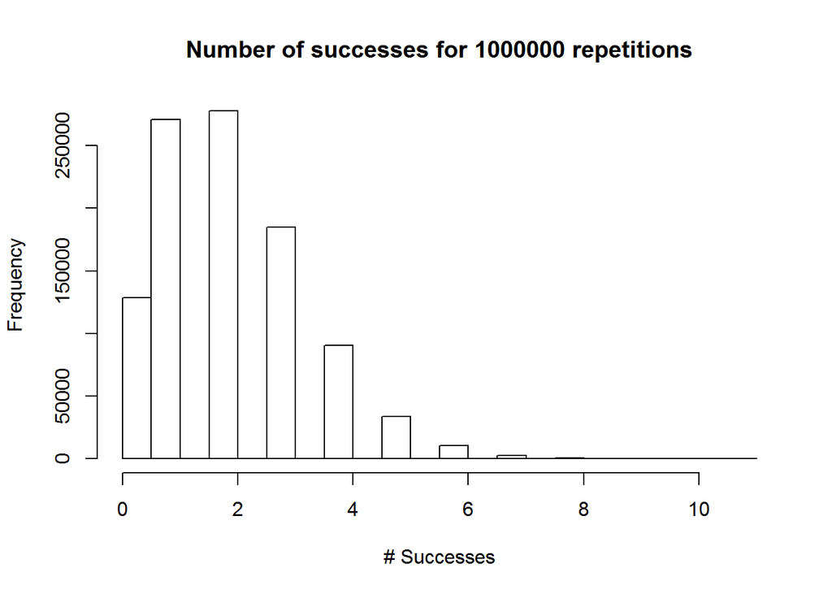

## Problem II

- (a): average (top) and standard deviation (bottom)

```
## [1] 1.998719
```

```
## [1] 1.377672
```

- (b): probability that all students remembered their hw

```
## [1] 0.128506
```

- (c): probability that at least 2 students forgot their hw

```
## [1] 0.600509
```

- (d): median number of students who forgot their hw

```
## [1] 2
```

## Problem III

- (a): Histogram of population, true mean (top), and true variance (bottom)

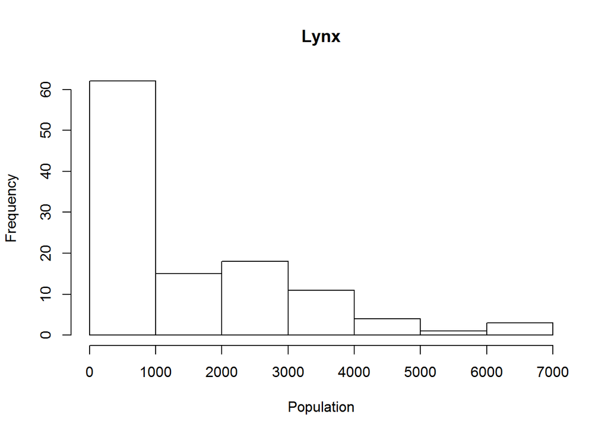

```
## [1] 1538.018
```

```
## [1] 2514901
```

- (b): Average with sample size n = 10

```
## [1] 1228.7
```

- (c): Mean (top) and Standard Deviation (Bottom) of vector of 1000000 means (multiple simulations of part b)

```
## [1] 1539.241
```

```
## [1] 479.1147
```

## Problem IV

- (a): Histogram from III (c)

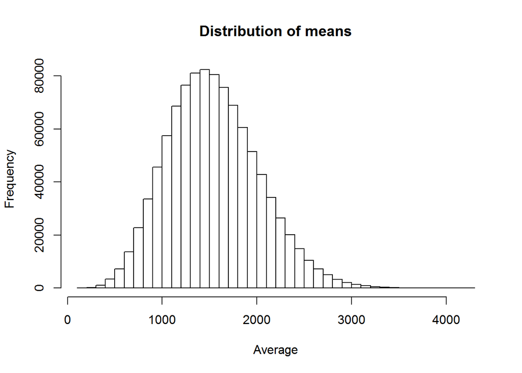

It is less skewed than the population distribution.

- (b): sample mean (top) and standard deviation (bottom) from a sample of 50

```
## [1] 1543.06
```

```
## [1] 1602.885
```

- (c): mean (top) and standard deviation (bottom) of 1000000 simulations’ means

```
## [1] 1537.992
```

```
## [1] 167.8907
```

The mean in III(c) stayed about the same, while the standard devation decreased.

- (d): Histogram of the vector in (c)

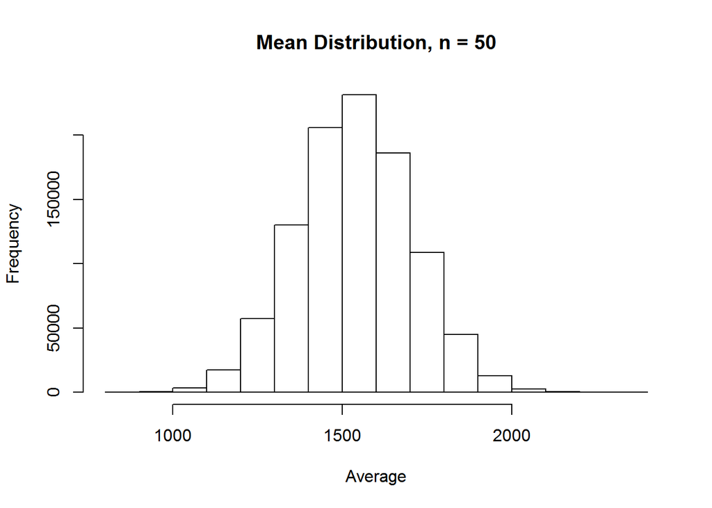

The shape is more symmetric now.

# Code Appendix

[output not shown]

[output cut: 75 more lines]

```
  simmean = mean(sample(lynx,50,replace = FALSE))
  return(simmean)
})
finalmean = mean(mean.of.means)
finalmean
finalsd = sd(mean.of.means)
finalsd

The mean in III(c) stayed about the same, while the standard devation decreased.

* (d): Histogram of the vector in (c)

hist(mean.of.means, main = "Mean Distribution, n = 50",xlab = "Average")

The shape is more symmetric now.
```